# ETC3250/5250 Introduction to Machine Learning

Week 5: Trees and forests

Jack Jewson

Jack.Jewson@monash.edu

Department of Econometrics and Business Statistics

## Overview

We will cover:

- Classification trees, algorithm, stopping rules
- Difference between algorithm and parametric methods, especially trees vs Logistic regression
- Forests: ensembles of bagged trees
- Diagnostics: vote matrix, variable importance
- Boosted trees

## Trees

[Nice explanation of trees, forests, boosted trees](https://bcullen.rbind.io/post/2020-06-02-tidymodels-decision-tree-learning-in-r/)

## What is a Decision Tree

LDA divided the predictor space up into $K$ regions, one for each response

Decision trees use a tree structure to divide up the feature space into regions with similar response behaviour

And predict the same response value (or probability) for observation in the same part of the tree

Consider trying to predict whether a customer would default on their credit card loan from their account balance and income

```
# A tibble: 5 × 4
  ID    Default Income Balance
  <chr> <chr>    <dbl>   <dbl>
1 obs1  No          71      26
2 obs2  No          65      30
3 obs3  Yes         55      36
4 obs4  No          76      45
5 obs5  Yes         68      53
```

## What is a Decision Tree

```
# A tibble: 5 × 4
  ID    Default Income Balance
  <chr> <chr>    <dbl>   <dbl>
1 obs1  No          71      26
2 obs2  No          65      30
3 obs3  Yes         55      36
4 obs4  No          76      45
5 obs5  Yes         68      53
```

Each **node** of a decision tree takes one variable and splits it at one point

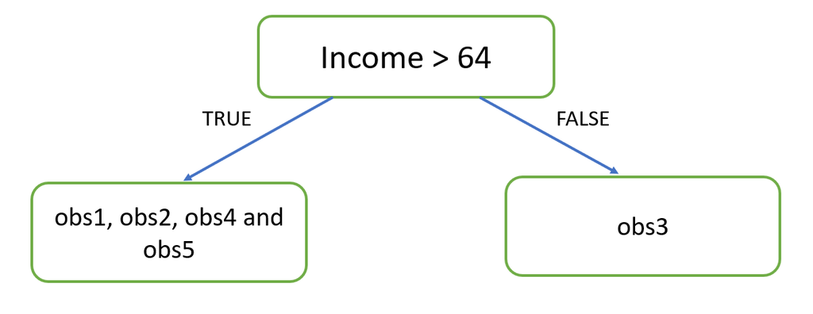

## What is a Decision Tree

```
# A tibble: 5 × 4
  ID    Default Income Balance
  <chr> <chr>    <dbl>   <dbl>
1 obs1  No          71      26
2 obs2  No          65      30
3 obs3  Yes         55      36
4 obs4  No          76      45
5 obs5  Yes         68      53
```

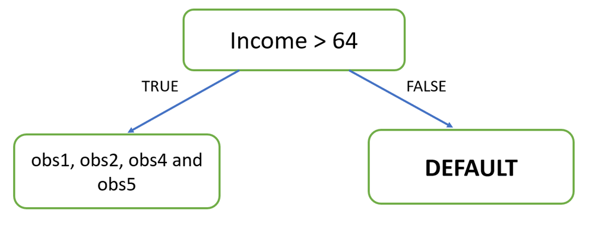

## What is a Decision Tree

```
# A tibble: 5 × 4
  ID    Default Income Balance
  <chr> <chr>    <dbl>   <dbl>
1 obs1  No          71      26
2 obs2  No          65      30
3 obs3  Yes         55      36
4 obs4  No          76      45
5 obs5  Yes         68      53
```

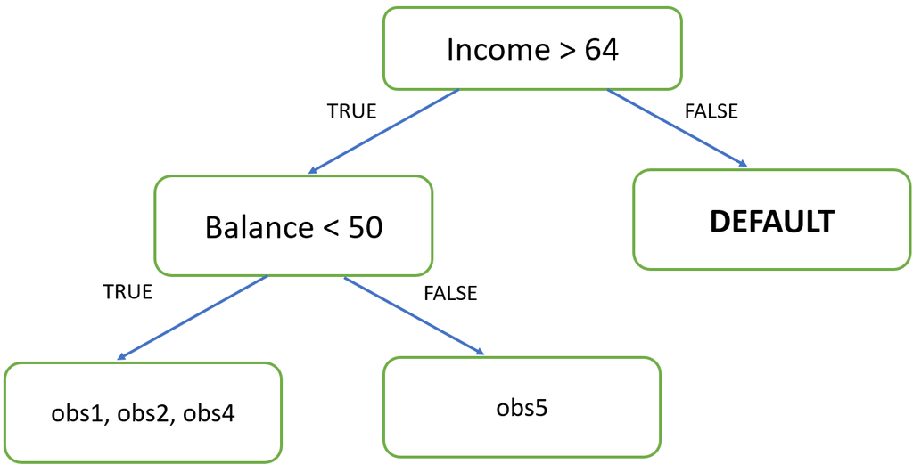

## What is a Decision Tree

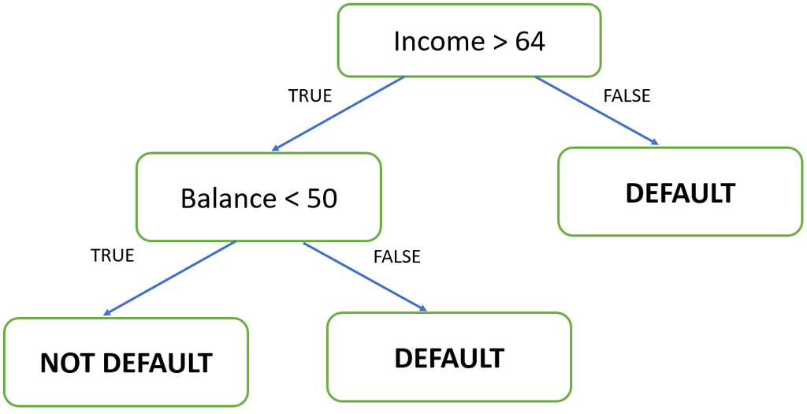

## What is a Decision Tree

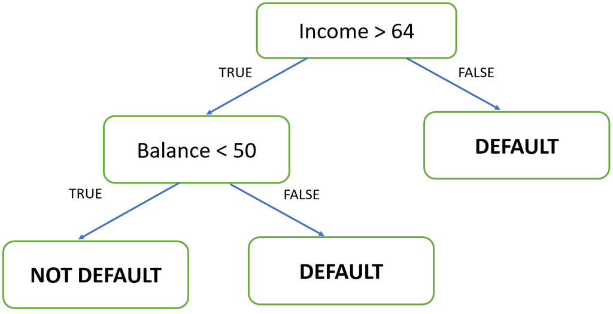

When a new observation arrives e.g. with `Income = 67` and `Balance = 20` we pass this observation through the tree.

`Income = 67` so Income > 64 is **TRUE**

`Balance = 20` so Balance < 50 is also **TRUE**

Then use the leaf node it appears in to predict its response and predict **NOT DEFAULT**

## What is a Decision Tree

Decision trees use a tree structure to divide up the feature space into regions with similar response behaviour

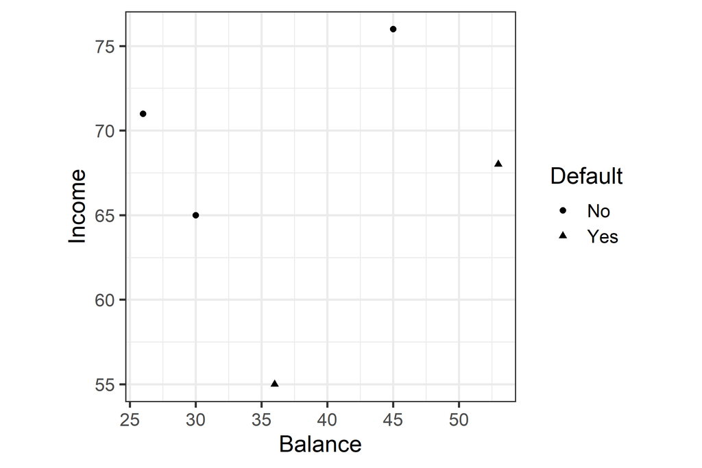

## What is a Decision Tree

Decision trees use a tree structure to divide up the feature space into regions with similar response behaviour

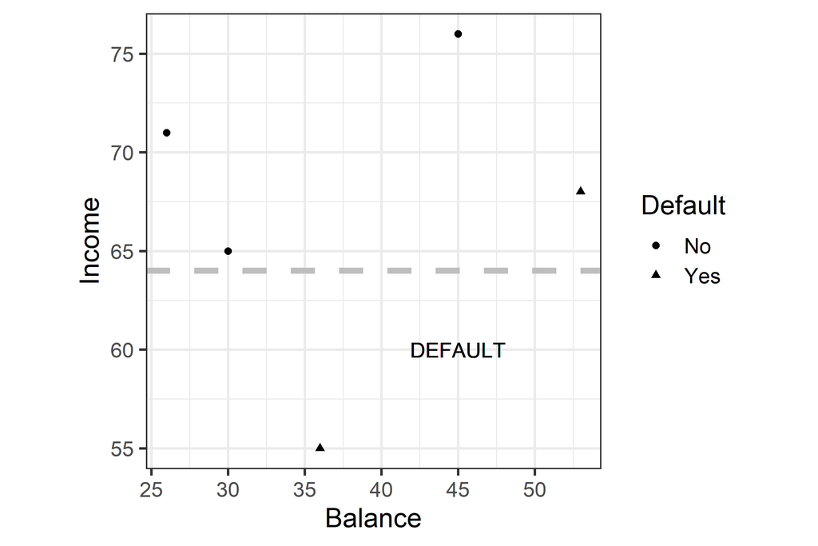

## What is a Decision Tree

Decision trees use a tree structure to divide up the feature space into regions with similar response behaviour

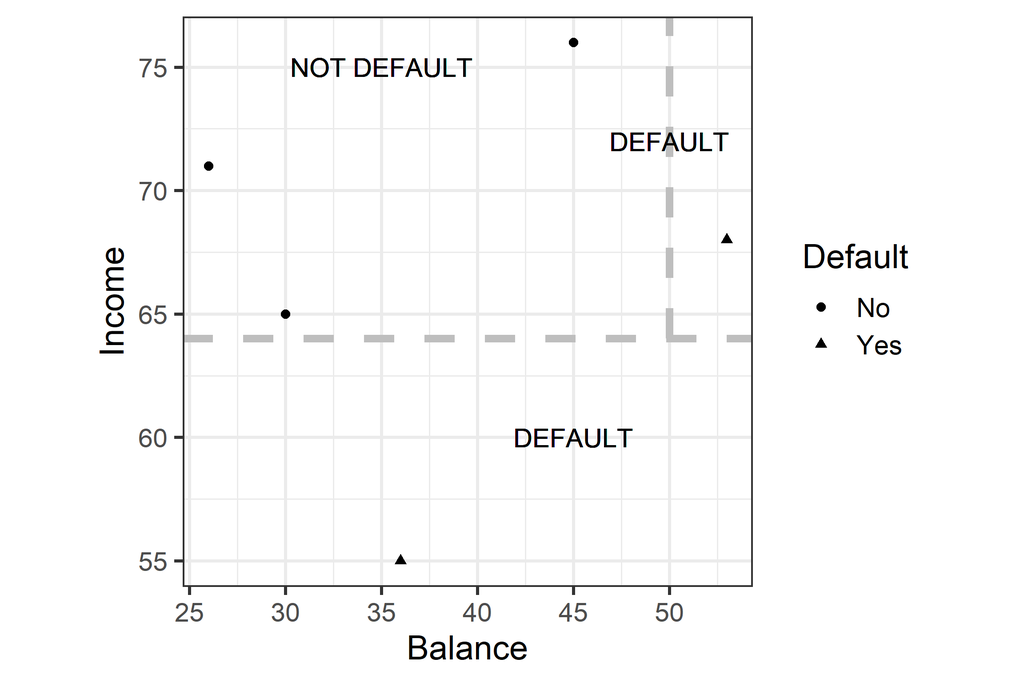

## What is a Decision Tree

Mathematically we can write a decision tree machine learning model as

$$g(x; \beta, R) = \sum_{m=1}^M \beta_m\mathbb{I}(x\in R_m)$$
where $\mathbb{I}(x\in R_m) = 1$ if $x\in R_m$ and $\mathbb{I}(x\not\in R_m) = 0$ otherwise.

For (binary) classification $P(Y = 1; x) = \frac{1}{1+e^{-g(x; \beta, R)}}$ (the logistic function)

For regression $\mathbb{E}[Y; x] = g(x; \beta, R)$

It is interesting to contrast this with (generalsied) linear models which sets$P(Y = 1; x) = \frac{1}{1+e^{-x^\top\beta}}$ for classification and $\mathbb{E}[Y; x] = x^\top\beta$ for regression.

The non-linear (non-parametric) tree function $g(x; \beta, R)$ takes the place of the linear predictor $x^\top\beta$

## What is a Decision Tree

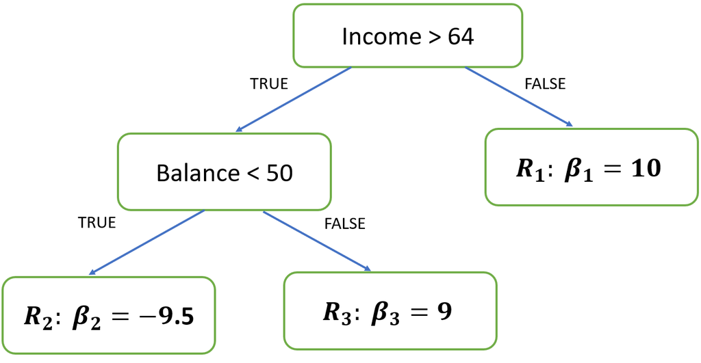

In $R_1$, the probability of defaulting is $P(Y = 1| x) = \frac{1}{1+e^{-10}} = 0.9999$

In $R_2$, the probability of defaulting is $P(Y = 1| x) = \frac{1}{1+e^{9.5}} = 0.0000748$

In $R_3$, the probability of defaulting is $P(Y = 1| x) = \frac{1}{1+e^{9}} = 0.99988$

## Fitting a Decision Tree

Fitting a decision tree to data requires

- Determining the regions $R_1, R_2, \ldots$ i.e. which variables to split and where
- Estimating the parameters for each region i.e. $\beta_1, \beta_2, \ldots$

Estimating the $\beta_1, \beta_2, \ldots$ for fixed values of the $R_1, R_2, \ldots$ is quite straightforward. We can use Maximum likelihood restricted for the training observations within each leaf node $R_m$.

Determining the regions $R_1, R_2, \ldots$ is more challenging. We will consider several different algorithms to do this

The idea, is to find the variable to split and the point to split by that makes the observations on the same branches after that split as similar as possible

## CART Algorithm: growing a tree

CART: Classification And Regression Trees

1. All observations in a single set
2. Sort values on first variable
3. Compute the chosen split criteria for all possible splits into two sets
4. Choose the best split on this variable. Save this info.
5. Repeat 2-4 for all other variables
6. Choose the best variable to split on, based on the best split. Your data is now in two sets.
7. Repeat 1-6 on each subset.
8. Stop when stopping rule that decides that the best classification model is achieved.

**Pros and cons**:

- Trees are a very flexible way to fit a classifier.
- They can
  - utilise different types of predictor variables
  - ignore missing values
  - handle different units or scales on variables
  - capture intricate patterns
- However, they operate on a per variable basis, and do not effectively model separation when a combination of variables is needed.
- Can be too flexible and need to be regularised to avoid overfitting

## Common split criteria

We want to split in ways the encourage observation with similar responses into the same split i.e. the child nodes have minimal variability in $y$

#### Classification

- The Gini index measures is defined as:
  $$G = \sum_{k =1}^K \widehat{p}_{mk}(1 - \widehat{p}_{mk})$$
  where $\widehat{p}_{mk}$ is the proportion of observation in subset $m$ of the data that belong to class $k$
- Gini is maximised at $\widehat{p}_{mk} = 0.5$ i.e. a 50:50 split, and minimised when $\widehat{p}_{mk} = 0$ or $1$
- (Note $p (1-p)$ is the variance of a Bernoulli distribution with success probability $p$)
- Entropy is defined as
  $$D = - \sum_{k =1}^K \widehat{p}_{mk} log(\widehat{p}_{mk})$$

## Common split criteria

We want to split in ways the encourage observation with similar responses into the same split i.e. the child nodes have minimal variability in $y$

#### Regression

Define

$$\mbox{Var}_m = \frac{1}{n_m}\sum_{i=1}^{n_m} (y_{mi} - \bar{y}_m)^2$$
where $\bar{y}_m$ is the average response in subset $m$

Split the data where combining Variance for left bucket (Var_L) and right bucket (Var_R), makes the biggest reduction from the overall Variance.

## Illustration (1/2)

| x | cl |
| --- | --- |
| 11 | A |
| 33 | A |
| 39 | B |
| 44 | A |
| 50 | A |
| 56 | B |
| 70 | B |

**Note**: x is sorted from lowest to highest!

All possible splits shown by vertical lines

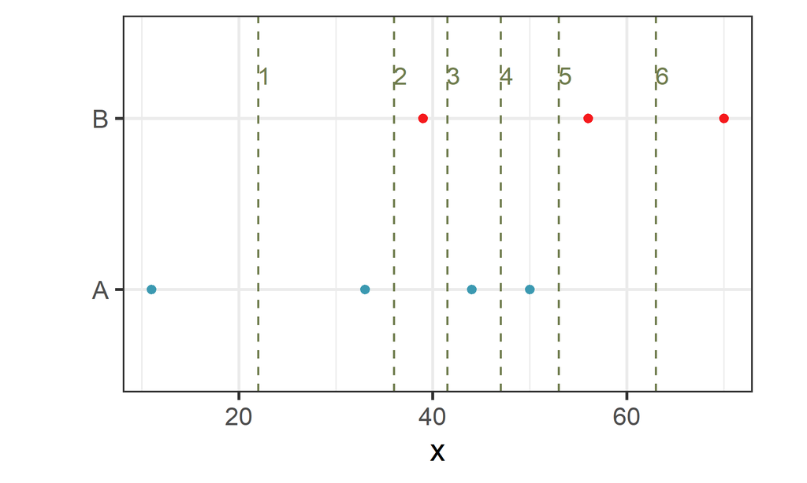

What do you think is the best split? 2, 3, 4 or 5??

You can see here that scale doesn’t matter

## Illustration (2/2)

#### Calculate the impurity for split 5

The left bucket is

| x | cl |
| --- | --- |
| 11 | A |
| 33 | A |
| 39 | B |
| 44 | A |
| 50 | A |

and the right bucket is

| x | cl |
| --- | --- |
| 56 | B |
| 70 | B |

Using Gini $G = \sum_{k =1}^K \widehat{p}_{mk}(1 - \widehat{p}_{mk})$

Left bucket:

$$\widehat{p}_{LA} = 4/5, \widehat{p}_{LB} = 1/5, ~~ p_L = 5/7$$

$$G_L=0.8(1-0.8)+0.2(1-0.2) = 0.32$$

Right bucket:

$$\widehat{p}_{RA} = 0/2, \widehat{p}_{RB} = 2/2, ~~ p_R = 2/7$$

$$G_R=0(1-0)+1(1-1) = 0$$

Combine with weighted sum to get impurity for the split:

$$p_LG_L + p_RG_R=0.23$$

**Your turn**: Compute the impurity for split 2.

## Categorical Predictors

**Splits on categorical variables**

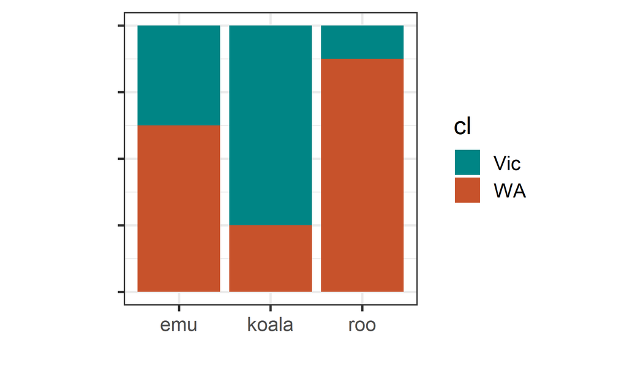

We can construct a split of one category vs the other e.g. {`koala`} vs {`roo`, `emu`}

Possible best split would be if koala then assign to Vic else assign to WA, because Vic has more koalas but and WA has more emus and roos.

**Dealing with missing values on predictors**

| x1 | x2 | x3 | x4 | y |
| --- | --- | --- | --- | --- |
| 19 | -8 | 22 | -24 | A |
| NA | -10 | 26 | -26 | A |
| 15 | NA | 32 | -27 | B |
| 17 | -6 | 27 | -25 | A |
| 18 | -5 | NA | -23 | A |
| 13 | -3 | 37 | NA | B |
| 12 | -1 | 35 | -30 | B |
| 11 | -7 | 24 | -31 | B |

50% of cases have missing values.

**Dealing with missing values on predictors**

| x1 | x2 | x3 | x4 | y |
| --- | --- | --- | --- | --- |
| 19 | -8 | 22 | -24 | A |
| NA | -10 | 26 | -26 | A |
| 15 | NA | 32 | -27 | B |
| 17 | -6 | 27 | -25 | A |
| 18 | -5 | NA | -23 | A |
| 13 | -3 | 37 | NA | B |
| 12 | -1 | 35 | -30 | B |
| 11 | -7 | 24 | -31 | B |

50% of cases have missing values.

Trees only work with a single variable at a time, so can easily just ignore a few missing values when calculating the plit criteria.

When predicting an observation with missing values, imputation is required

## Example: penguins 1/6

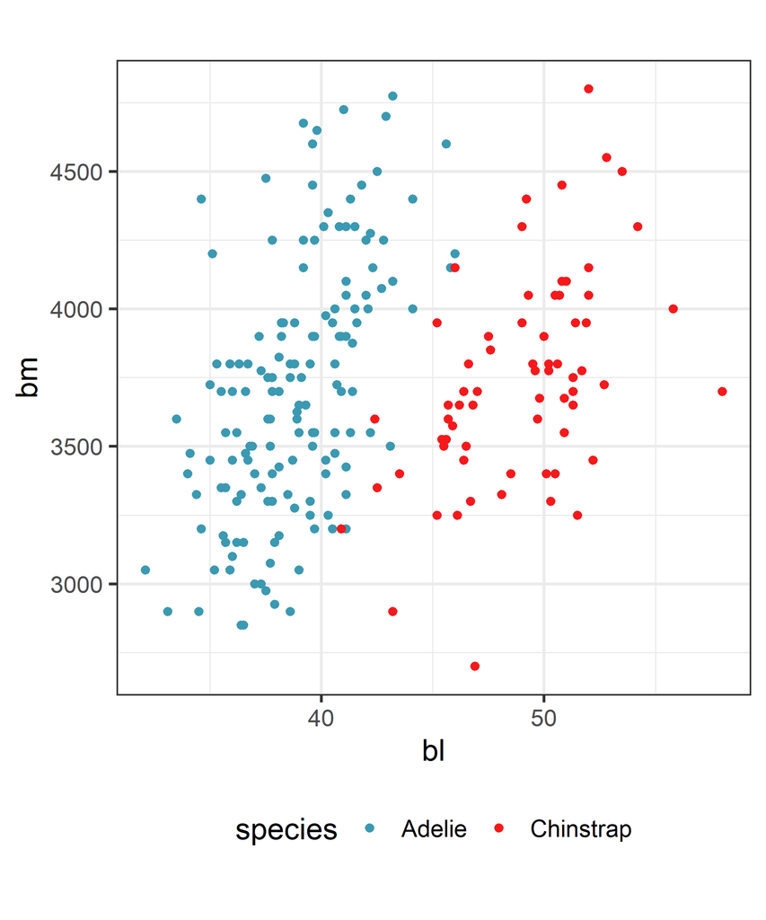

See https://parsnip.tidymodels.org/reference/decision_tree.html

```r
set.seed(1156)
p_split <- initial_split(p_sub, 2/3, strata=species)
p_tr <- training(p_split)
p_ts <- testing(p_split)

tree_spec <- decision_tree() |>
  set_mode("classification") |>
  set_engine("rpart")

p_fit_tree <- tree_spec |>
  fit(species~., data=p_tr)
```

```r
p_fit_tree
```

```
parsnip model object

n= 145

node), split, n, loss, yval, (yprob)
      * denotes terminal node

1) root 145 45 Adelie (0.690 0.310)
  2) bl< 43 99  2 Adelie (0.980 0.020) *
  3) bl>=43 46  3 Chinstrap (0.065 0.935) *
```

## Example: penguins 2/6

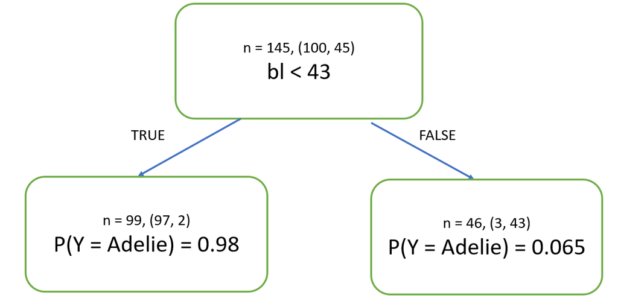

## Example: penguins 3/6

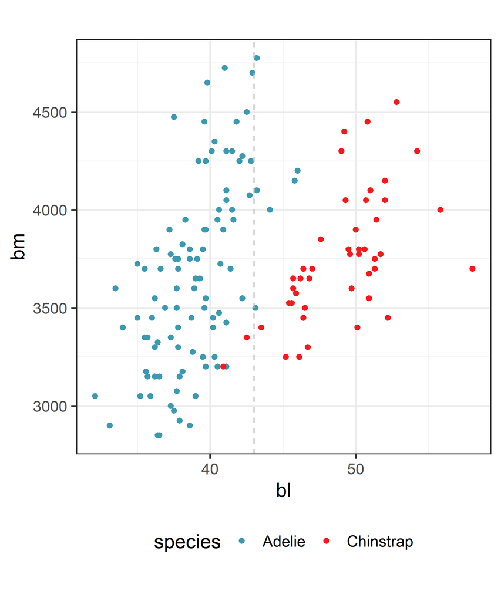

## Stopping rules

- Minimum split: number of observations in a node, in order for a split to be made
- Tree depth: The maximum number of splits between the a terminal node and root node
- Complexity parameter: minimum difference between impurity values required to continue splitting

## Example: penguins 4/6

Defaults for `rpart` are:

```
rpart.control(minsplit = 20,
  cp = 0.01,
  maxdepth = 30,
  ...)
```

```r
tree_spec <- decision_tree() |>
  set_mode("classification") |>
  set_engine("rpart",
             control = rpart.control(minsplit = 10),
             model=TRUE)

p_fit_tree <- tree_spec |>
  fit(species~., data=p_tr)
```

```r
p_fit_tree
```

```
parsnip model object

n= 145

node), split, n, loss, yval, (yprob)
      * denotes terminal node

 1) root 145 45 Adelie (0.690 0.310)
   2) bl< 43 99  2 Adelie (0.980 0.020)
     4) bl< 41 75  0 Adelie (1.000 0.000) *
     5) bl>=41 24  2 Adelie (0.917 0.083)
      10) bm>=3.4e+03 21  0 Adelie (1.000 0.000) *
      11) bm< 3.4e+03 3  1 Chinstrap (0.333 0.667) *
   3) bl>=43 46  3 Chinstrap (0.065 0.935)
     6) bl< 46 10  3 Chinstrap (0.300 0.700)
      12) bm>=3.8e+03 3  0 Adelie (1.000 0.000) *
      13) bm< 3.8e+03 7  0 Chinstrap (0.000 1.000) *
     7) bl>=46 36  0 Chinstrap (0.000 1.000) *
```

## Example: penguins 5/6

```r
p_fit_tree |>
  extract_fit_engine() |>
  rpart.plot(type=3, extra=1)
```

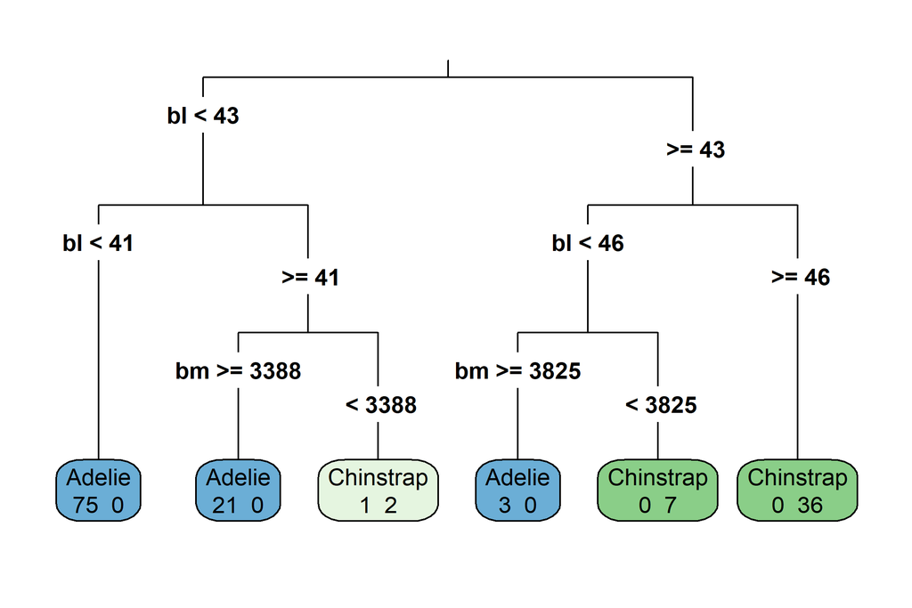

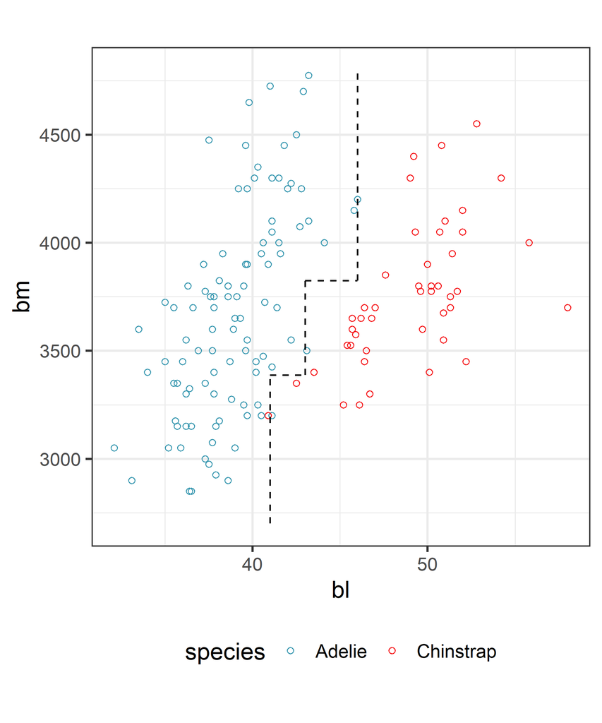

## Example: penguins 6/6

Model fit summary

```
# A tibble: 1 × 3
  .metric  .estimator .estimate
  <chr>    <chr>          <dbl>
1 accuracy binary         0.946
```

```
# A tibble: 2 × 4
# Groups:   species [2]
  species   Adelie Chinstrap Accuracy
  <fct>      <int>     <int>    <dbl>
1 Adelie        50         1    0.980
2 Chinstrap      3        20    0.870
```

```
# A tibble: 1 × 3
  .metric      .estimator .estimate
  <chr>        <chr>          <dbl>
1 bal_accuracy binary         0.925
```

Model-in-the-data-space

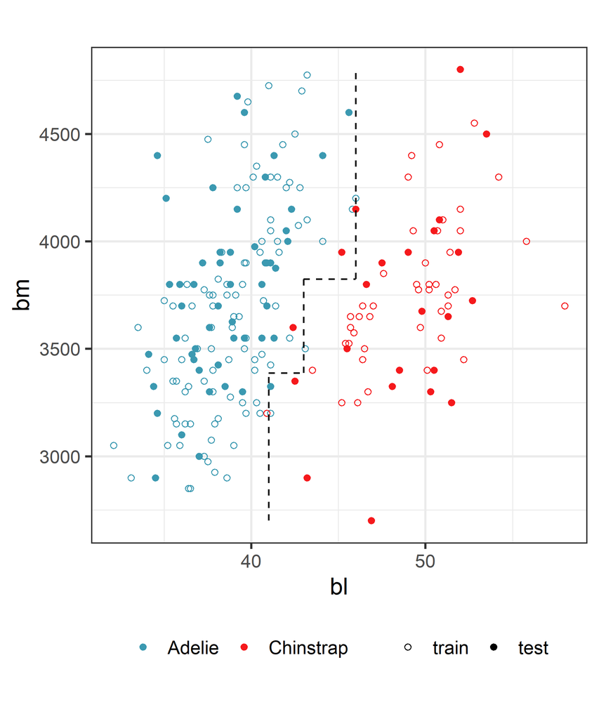

## Comparison with logistic regression

Tree model

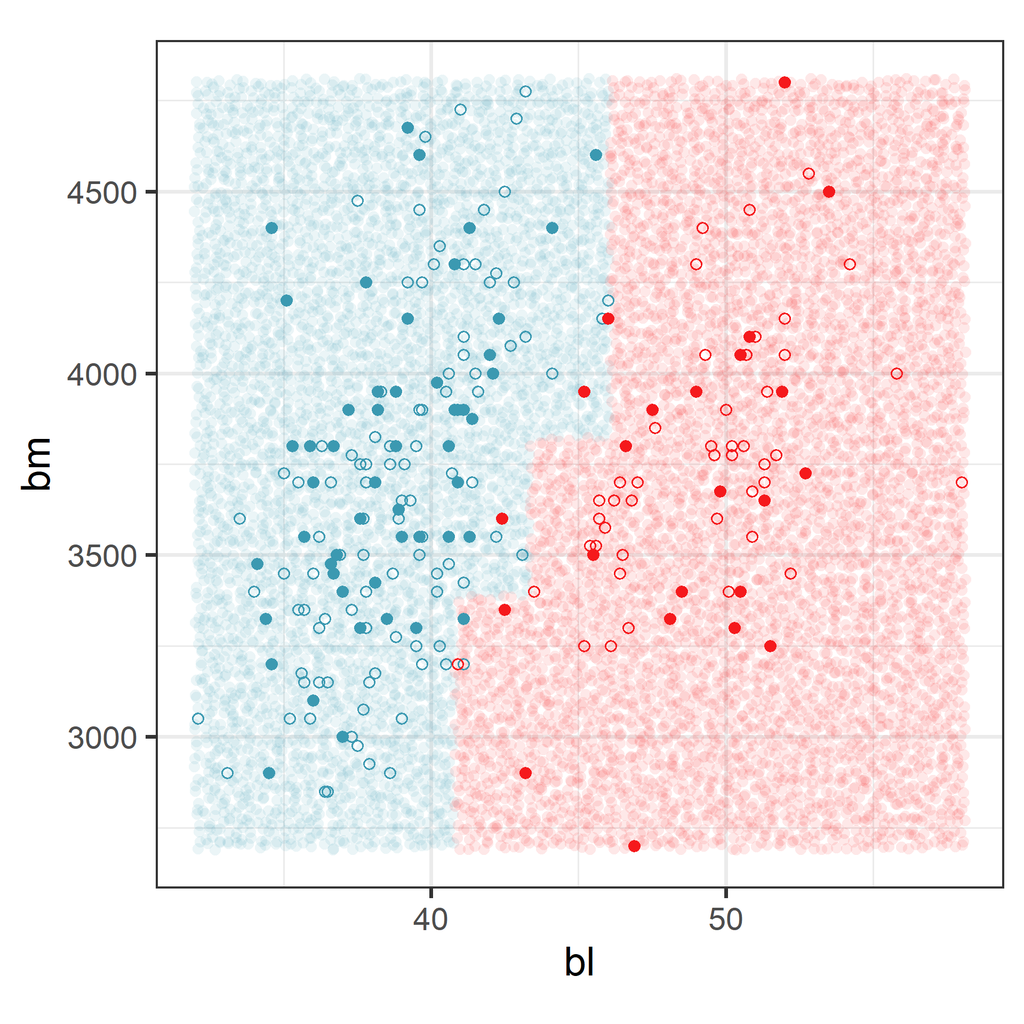

Data-driven, only split on single variables

Logistic regression model

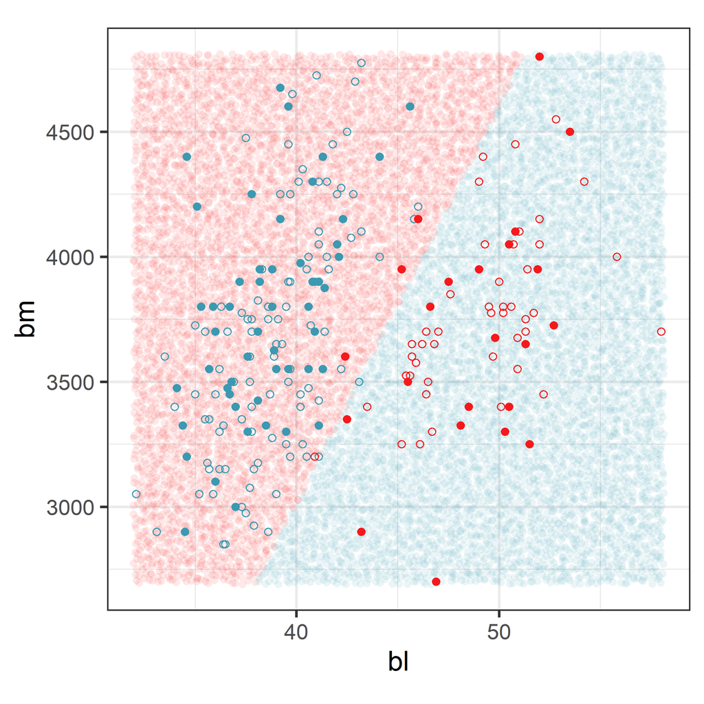

oblique splits (combination fo variables)

## Learning tree hyperparameters

For given stopping rules, the CART algorithm learns the splits and the reponse parameter in each terminal node.

However, it doesn’t tell us what stopping rule to use, i.e. which values of `minsplit`, `cp`, and `maxdepth` to use

These are our tree hyper parameters that we learn by cross-validation

Cross-validation splits the **training data** into disjoint subset, and iteratively uses one as a *mini* test set the evaluate the model fitted on the remaining sets

## Cross-validation in the `tidymodels`

```r
tune_spec <-
  decision_tree(
    cost_complexity = tune(),
    tree_depth = tune(),
    min_n = tune()
  ) |>
  set_engine("rpart") |>
  set_mode("classification")
```

```r
tree_grid <- grid_regular(cost_complexity(),
                          tree_depth(),
                          min_n(),
                          levels = 5)
```

```r
unique(tree_grid$cost_complexity)
```

```
[1] 1.0e-10 1.8e-08 3.2e-06 5.6e-04 1.0e-01
```

```r
unique(tree_grid$tree_depth)
```

```
[1]  1  4  8 11 15
```

```r
unique(tree_grid$min_n)
```

```
[1]  2 11 21 30 40
```

```r
set.seed(234)
p_folds <- vfold_cv(p_tr, v = 5, strata = species)
```

```r
set.seed(345)

tree_wf <- workflow() |>
  add_model(tune_spec) |>
  add_formula(species~.)
```

```r
tree_res <-
  tree_wf |>
  tune_grid(
    resamples = p_folds,
    grid = tree_grid,
    metrics = NULL #NULL to compute a standard set of metrics.
    )
```

```r
tree_res |>
  collect_metrics() |>
  slice_head(n = 6)
```

```
# A tibble: 6 × 9
  cost_complexity tree_depth min_n .metric .estimator   mean
            <dbl>      <int> <int> <chr>   <chr>       <dbl>
1    0.0000000001          1     2 accura… binary     0.959
2    0.0000000001          1     2 brier_… binary     0.0405
3    0.0000000001          1     2 roc_auc binary     0.952
4    0.0000000178          1     2 accura… binary     0.959
5    0.0000000178          1     2 brier_… binary     0.0405
6    0.0000000178          1     2 roc_auc binary     0.952
# ℹ 3 more variables: n <int>, std_err <dbl>, .config <chr>
```

## Cross-validation in the `tidymodels`

```r
tree_res |>
  show_best(metric = "roc_auc")
```

```
# A tibble: 5 × 9
  cost_complexity tree_depth min_n .metric .estimator  mean
            <dbl>      <int> <int> <chr>   <chr>      <dbl>
1    0.0000000001          1     2 roc_auc binary     0.952
2    0.0000000178          1     2 roc_auc binary     0.952
3    0.00000316            1     2 roc_auc binary     0.952
4    0.000562              1     2 roc_auc binary     0.952
5    0.1                   1     2 roc_auc binary     0.952
# ℹ 3 more variables: n <int>, std_err <dbl>, .config <chr>
```

```r
tree_res |>
  select_best(metric = "roc_auc")
```

```
# A tibble: 1 × 4
  cost_complexity tree_depth min_n .config
            <dbl>      <int> <int> <chr>
1    0.0000000001          1     2 Preprocessor1_Model001
```

For more information see - https://www.tidymodels.org/start/tuning/

## Argument names

**rpart**

- Minimum split = `minsplit`
- Tree depth = `maxdepth`
- Complexity parameter = `cp`

```r
tree_spec <- decision_tree() |>
  set_mode("classification") |>
  set_engine("rpart",
             control = rpart.control(minsplit = 10),
             model=TRUE)
```

**tidymodels**

- Minimum split = `min_n`
- Tree depth = `tree_depth`
- Complexity parameter = `cost_complexity`

```r
tree_spec <-
  decision_tree(
    min_n = 10
  ) |>
  set_engine("rpart") |>
  set_mode("classification")
```

## Decision tree limitations

Decision trees provide us with an extremely powerful machine learning model

It can capture complex non-linear dynamics, using a tree to divide up the predictor space and group similar training observations togther.

A major limitation of decision trees is that they are too flexible - it is very easy for them to perfectly classify the training data

This means they can very easily overfit the data - learn about the noise in the observed data rather than the signal in the process that generated the data

Learning the stopping criteria via cross-validation prevents this overfitting, but often leads to conservative models that don’t fully exploit the DTs power

## Random forests

## From Trees to Forests

A forest is an ensemble classifier, built from fitting and combining multiple trees.

Remember we wrote our machine learning decision tree model as
$$g(x; \beta, R) = \sum_{m=1}^M \beta_m\mathbb{I}(x\in R_m)$$

A tree ensemble uses
$$g(x; \beta, R) = \sum_{t=1}^T \alpha_t g_t(x; \beta_t, R_t)$$
where $g_t(x; \beta_t, R_t)$ are individual decision trees and $\alpha_t$ is a weight for each tree

## Overview

A random forest is an ensemble classifier, built from fitting multiple trees to different subsets of the training data.

If we fit $T$ trees then $\alpha_t = \frac{1}{T}$ and each $g_t(x; \beta_t, R_t)$ is a decision tree estimated on a different subset of the data

These subsets are generated by

- boostrapping observations (sampling with replacement)
- sampling columns without replacement

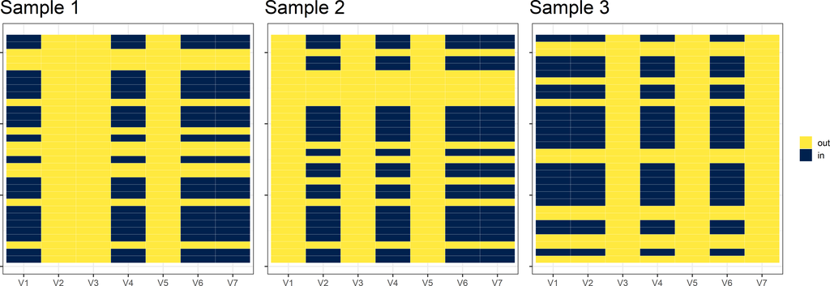

## Bagging and variable sampling

- Take $T$ different bootstrapped training sets: $D_1, D_2, \dots, D_T$, each using a sample of variables.
- Build a separate prediction model using each $D_{(\cdot)}$:
  $$\widehat{g}_1(x), \widehat{g}_2(x), \dots, \widehat{g}_T(x)$$
- Predict the **out-of-bag** cases for each tree

Random forests directly try to address the bias variance tradeoff

- Each individual tree has the same bias
- Aggregating trees leave the bias unchanged
- Each individual tree has high variance i.e. can easily overfit its training data.
- Aggregating the results from $T$ trees reduces the variance as different trees were trained on different data, so the ensembles can not overfit any one dataset.

Should still use cross-validation to learn stopping rules that are used in each tree of the forest

## Comparison with a single tree and LDA

Tree model

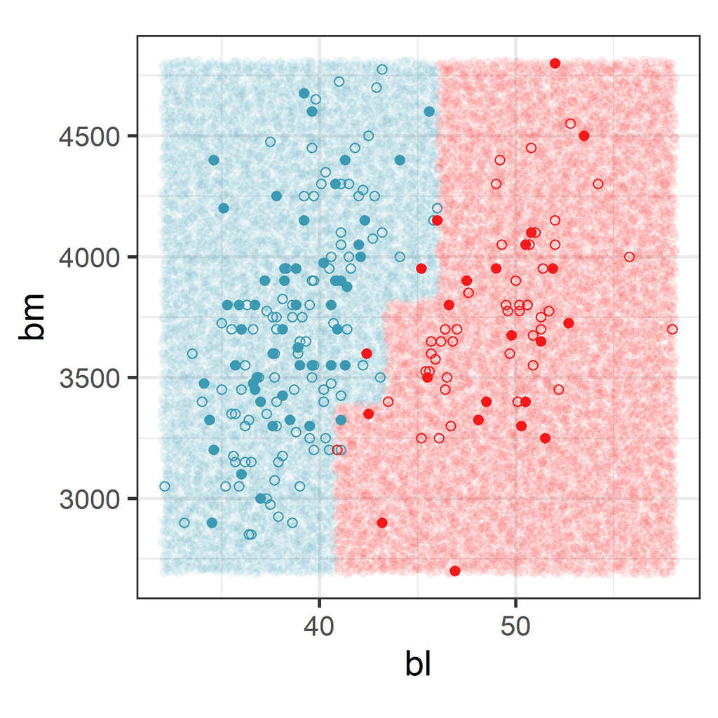

Data-driven, only split on single variables

Random forest

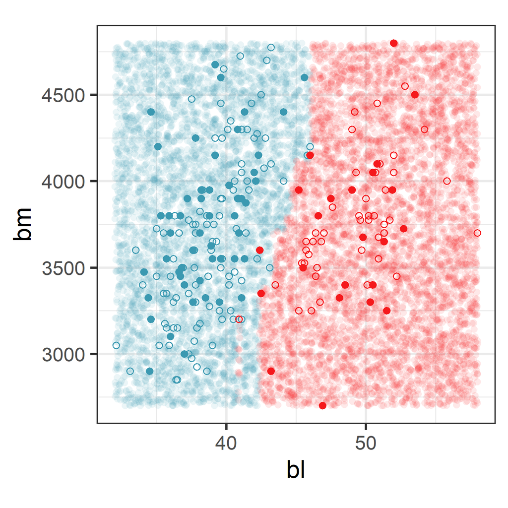

Data-driven, multiple trees gives non-linear fit

Logistic regression model

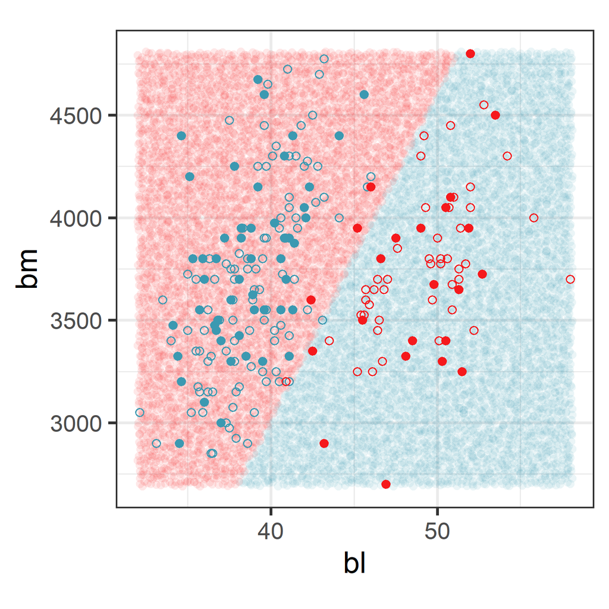

Assume normal, equal VC, oblique splits

## Random forest fit and predicted values

See - https://parsnip.tidymodels.org/reference/rand_forest.html

```r
rf_spec <- rand_forest(mtry=2, trees=1000) |>
  set_mode("classification") |>
  set_engine("randomForest")
p_fit_rf <- rf_spec |>
  fit(species ~ ., data = p_tr)
```

```r
p_fit_rf
```

```
parsnip model object


Call:
 randomForest(x = maybe_data_frame(x), y = y, ntree = ~1000, mtry = min_cols(~2,      x))
               Type of random forest: classification
                     Number of trees: 1000
No. of variables tried at each split: 2

        OOB estimate of  error rate: 4.8%
Confusion matrix:
          Adelie Chinstrap class.error
Adelie        96         4       0.040
Chinstrap      3        42       0.067
```

Predicted values

```
# A tibble: 1 × 3
  .metric  .estimator .estimate
  <chr>    <chr>          <dbl>
1 accuracy binary         0.973
```

```
# A tibble: 2 × 4
# Groups:   species [2]
  species   Adelie Chinstrap Accuracy
  <fct>      <int>     <int>    <dbl>
1 Adelie        51         0    1
2 Chinstrap      2        21    0.913
```

```
# A tibble: 1 × 3
  .metric      .estimator .estimate
  <chr>        <chr>          <dbl>
1 bal_accuracy binary         0.957
```

Warning: Don’t use the `predict()` on the training set, you’ll always get 0 error. The object `p_fit_rf$fit$predict` has the fitted values.

## Vote Matrix

```r
p_fit_rf$fit$votes
```

```
    Adelie Chinstrap
1   1.0000    0.0000
2   1.0000    0.0000
3   0.9807    0.0193
4   1.0000    0.0000
5   1.0000    0.0000
6   1.0000    0.0000
7   1.0000    0.0000
8   0.3982    0.6018
9   1.0000    0.0000
10  1.0000    0.0000
11  1.0000    0.0000
12  0.8274    0.1726
13  0.3425    0.6575
14  1.0000    0.0000
```

[output cut: 133 more lines]

- For each tree, predict the class (probability) for each out-of-bag observation
- Average across trees where this observation was oob ranges between 0-1
- Can be used to identify troublesome cases.
- Used with plots of the actual data can help determine if it is the record itself that is the problem, or if method is biased.
- Understand the difference in accuracy of prediction for different classes.
- in-sample out-of-sample accuracy

## Variable importance (1/2)

Each split only depends on one variable

Gini importance adds up the difference in impurity value of the descendant nodes with the parent node for any split involving that variable. Quick to compute.

Alternatively,

1. For every tree predict the oob cases and count the number of votes cast for the correct class.
2. Randomly permute the values on a variable in the oob cases and predict the class for these cases.
3. Difference the votes for the correct class in the variable-permuted oob cases and the real oob cases. Average this number over all trees in the forest. If the value is large, then the variable is very important.

Read a fun explanation by [Harriet Mason](https://numbat.space/posts/permutation_variable_importance/)

## Variable importance (2/2)

```r
p_fit_rf$fit$importance
```

```
   MeanDecreaseGini
bl             57.2
bm              4.5
```

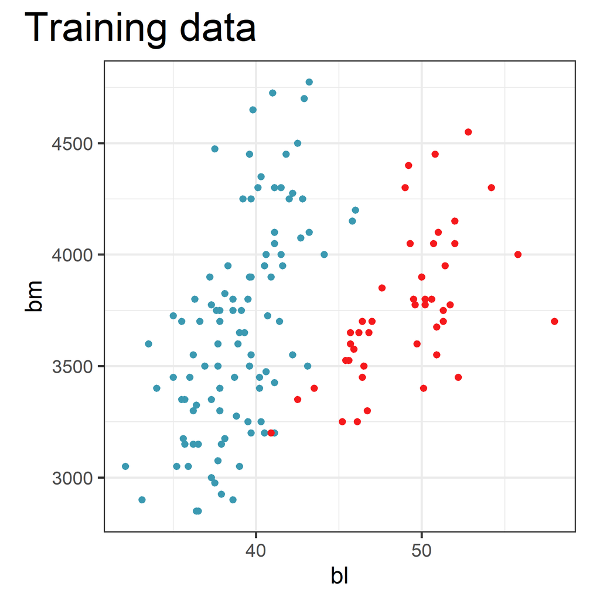

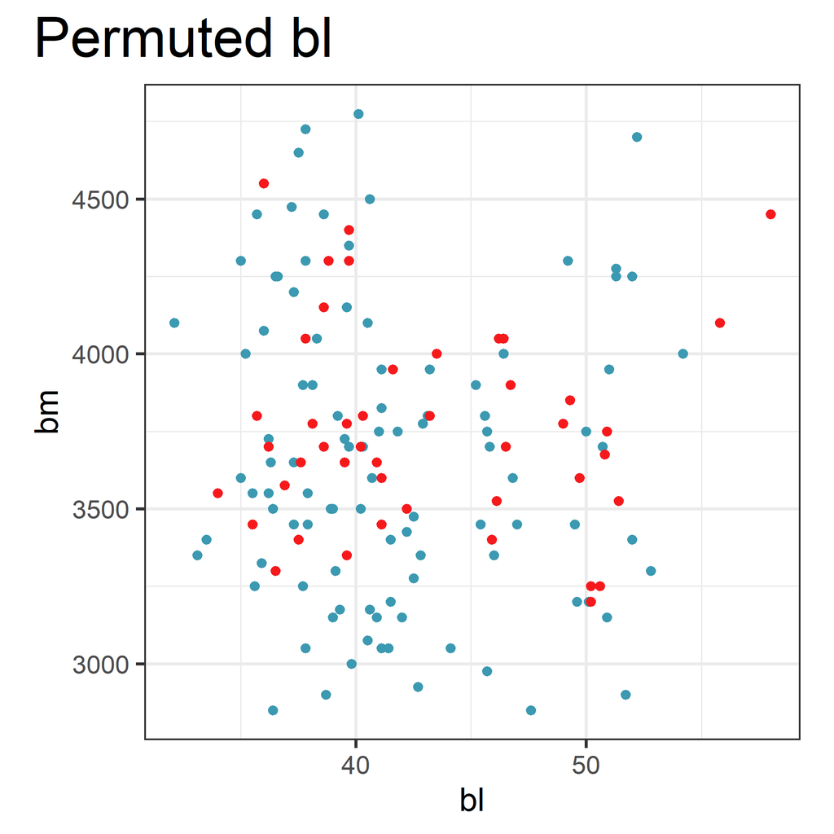

```r
p_tr_perm <- p_tr |>
  mutate(bl = sample(bl))
ggplot(p_tr_perm, aes(x=bl, y=bm, colour=species)) +
  geom_point()  +
  scale_color_discrete_divergingx(palette = "Zissou 1") +
  ggtitle("Permuted bl") +
  theme(legend.position="none")
```

## Utilising diagnostics (1/3)

Probabilities yields more information than the confusion matrix, about the confidence that the model has in the prediction for each observation, in the training set.

Let’s re-fit the random forest model to the three species of the penguins.

And examine the votes matrix

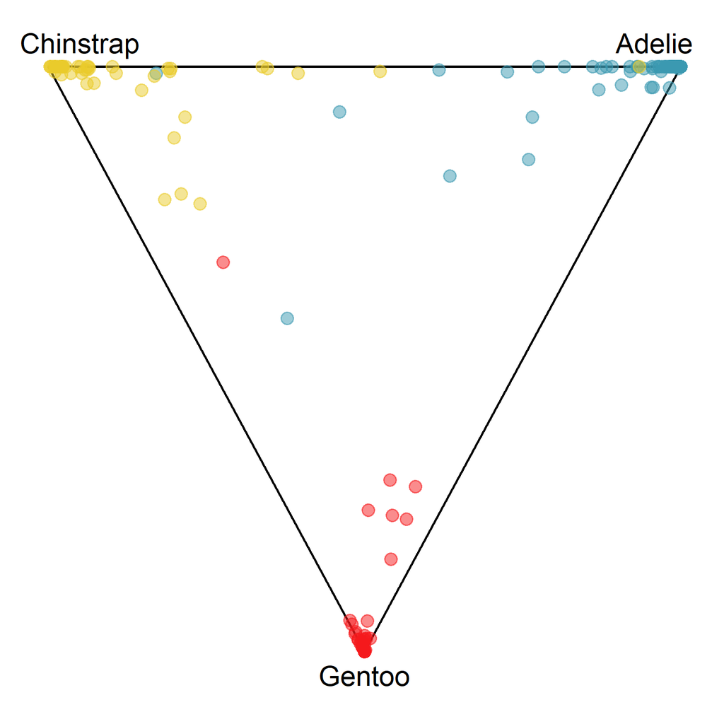

```r
p_ternary
```

## Utilising diagnostics (2/3)

DEMO: Use interactivity to investigate the uncertainty in the predictions.

```r
library(detourr)
library(crosstalk)
library(plotly)
library(viridis)
p_tr2_std <- p_tr2 |>
  mutate_if(is.numeric, function(x) (x-mean(x))/sd(x))
p_tr2_v <- bind_cols(p_tr2_std, p_rf_v_p[,1:2])
p_tr2_v_shared <- SharedData$new(p_tr2_v)

detour_plot <- detour(p_tr2_v_shared, tour_aes(
  projection = bl:bm,
  colour = species)) |>
    tour_path(grand_tour(2),
                    max_bases=50, fps = 60) |>
       show_scatter(alpha = 0.9, axes = FALSE,
                    width = "100%",
                    height = "450px",
                    palette = hcl.colors(3,
                      palette="Zissou 1"))

vot_mat <- plot_ly(p_tr2_v_shared,
                    x = ~x1,
                    y = ~x2,
                    color = ~species,
                    colors = hcl.colors(3,
                        palette="Zissou 1"),
                    height = 450) |>
  highlight(on = "plotly_selected",
              off = "plotly_doubleclick") |>
    add_trace(type = "scatter",
              mode = "markers")

bscols(
     detour_plot, vot_mat,
     widths = c(5, 6)
 )
```

## Utilising diagnostics (3/3)

Variable importance can help with variable selection.

```r
p_fit_rf2$fit$importance
```

```
   MeanDecreaseGini
bl               58
bd               28
fl               45
bm               12
```

Top two variables are `bl` and `fl`.

Especially useful when you have many more variables.

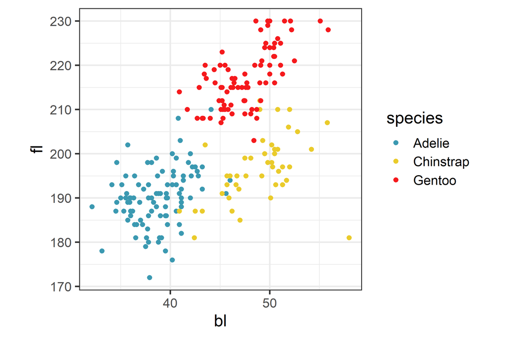

## Boosting

## Boosted trees (1/4)

Random forests build an ensemble of independent trees, while boosted trees build an ensemble from shallow trees in a sequence with each tree learning and improving on the mistakes of previous ones.

Source: [Boehmke (2020) Hands on Machine Learning with R](https://bradleyboehmke.github.io/HOML/)

## From Trees to Forests to Boosting

Boosting is also an ensemble classifier that also uses a forest of trees. Boosting however iteratively build trees to correct for errors of previous trees.

Remember we wrote our machine learning decision tree model as
$$g(x; \beta, R) = \sum_{m=1}^M \beta_m\mathbb{I}(x\in R_m)$$

A tree ensemble uses
$$g(x; \beta, R) = \sum_{t=1}^T \alpha_t g_t(x; \beta_t, R_t)$$
where $g_t(x; \beta_t, R_t)$ are individual decision trees and $\alpha_t$ is a weight for each tree

## From Trees to Forests to Boosting

Boosting is also an ensemble classifier that also uses a forest of trees. Boosting however iteratively build trees to correct for errors of previous trees.

Random forests took weight $\alpha_t = \frac{1}{T}$ and built each tree $g_t(x; \beta_t, R_t)$ using a random subset of observations and variables in the data. Each tree was independent of the previous trees

Boosting learns weight $\alpha_t\in(0, 1)$ and tree $g_t(x; \beta_t, R_t)$ to improve upon the performance of the previous $t-1$ trees.

Doesn’t change previous trees and adds one tree to the ensemble at a time.

## Boosted trees (2/4)

Boosting iteratively fits multiple trees, to correct errors made by previous trees.

1. Fit a tree with fixed $m$ splits ($m+1$ terminal nodes) to the whole data set ($m$ is often taken small to make sure each tree can’t overfit).
2. For $t=2, \ldots, T$, repeat:
   1. Compute errors of ensemble to date - $g(x; \beta, R) = \sum_{k=1}^{t-1} \alpha_k g_k(x; \beta_k, R_k)$
   2. Fit tree $g_t(x; \beta_t, R_t)$ and $\alpha_t$ to best correct for these errors
3. Aggregate predictions from all trees - $g(x; \beta, R) = \sum_{t=1}^{T} \alpha_t g_t(x; \beta_t, R_t)$.

This [StatQuest video by Josh Starmer](https://www.youtube.com/embed/jxuNLH5dXCs), is the best explanation!

And this is a fun explanation of boosting [by Harriet Mason](https://numbat.space/posts/boosting/).

## Boosted trees (3/4)

There are two main strategies to fit a new tree to improve errors of past trees

Reweight observations, upweighting those that were predicted poorly before and downweighting those that were predicted well - known as **AdaBoost**

Introduces a weight $w_i \in (0, 1)$ for each observation and use these weight when computing splitting criteria e.g. Gini would use weighted proportions

Calculate residuals or pseudo-residuals of the ensemble so far for each observation’s reponse, and train subsequent trees on this- known as **Gradient Boosting**

## Boosted trees (4/4)

```r
set.seed(1110)
bt_spec <- boost_tree() |>
  set_mode("classification") |>
  set_engine("xgboost")
p_fit_bt <- bt_spec |>
  fit(species ~ ., data = p_tr2)
```

```
# A tibble: 1 × 3
  .metric  .estimator .estimate
  <chr>    <chr>          <dbl>
1 accuracy multiclass     0.991
```

```
# A tibble: 3 × 5
# Groups:   species [3]
  species   Adelie Chinstrap Gentoo Accuracy
  <fct>      <int>     <int>  <int>    <dbl>
1 Adelie        50         1      0    0.980
2 Chinstrap      0        23      0    1
3 Gentoo         0         0     41    1
```

## Limitations of trees

- Most implementations only splits on a single variable, not combinations.
- There are versions that build trees on combinations, eg [PPTreeViz](https://cran.r-project.org/web/packages/PPtreeViz/index.html) and [PPforest](https://natydasilva.github.io/PPforest/), but you lose interpretability, and fitting is more difficult.
- Sees only splits, but not gaps. (See support vector machines, in a few weeks.)
- Need tuning and cross-validation.

## Next: Neural networks and deep learning

ETC3250/5250 Lecture 5